# lab4

```r
library(runjags)
```

```r
library(ggplot2)
library(coda)

setwd("C:/Users/Gorge-PC/Documents")
dramadata = read.csv("KDramaData.csv", header=T)
```

question 1

```r
modelString <-"
model {

## likelihod
for(i in 1:N){
  y[i] ~ dnorm(mu_j[schedule[i]], invsigma2)
}

## priors

for (j in 1:J){
  mu_j[j] ~ dnorm(mu, invtau2)T(0,)
}

invsigma2 ~ dgamma(a_g, b_g)
sigma <- sqrt(pow(invsigma2, -1))

##hyperpriors
mu ~ dnorm(mu0, 1/g0^2)
invtau2 ~ dgamma(a_t, b_t)
tau <- sqrt(pow(invtau2, -1))

}
"

y = dramadata$Rating        # The y values are in the column named Rating
schedule = dramadata$Schedule      # The schedule index is in the column named Schedule
N = length(y)  # Compute the number of observations
J = length(unique(schedule)) # Compute the number of schedules/subsamples

initsfunction <- function(chain){
  .RNG.seed <- c(1,2)[chain]
  .RNG.name <- c("base::Super-Duper",
                 "base::Wichmann-Hill")[chain]
  return(list(.RNG.seed=.RNG.seed,
              .RNG.name=.RNG.name))
}

the_data <- list("y" = y, "schedule" = schedule, "N" = N, "J" = J,
                 "mu0" = 0.1, "g0" = 0.5,
                 "a_t" = 1, "b_t" = 1,
                 "a_g" = 1, "b_g" = 1)

posterior <- run.jags(modelString,
                      n.chains = 1,
                      data = the_data,
                      monitor = c("mu", "tau", "mu_j", "sigma"),
                      adapt = 1000,
                      burnin = 5000,
                      sample = 5000,
                      thin = 1,
                      inits = initsfunction)
```

[output not shown]

```
## Finished running the simulation
```

```r
options(digits = 3)
summary(posterior)
```

```
##           Lower95  Median Upper95    Mean     SD Mode    MCerr MC%ofSD
## mu      -1.35e+00 -0.5368   0.225 -0.5388 0.4064   NA 0.007447     1.8
## tau      3.39e-01  0.5924   1.048  0.6384 0.2157   NA 0.003742     1.7
## mu_j[1]  3.43e-02  0.0880   0.137  0.0877 0.0261   NA 0.000368     1.4
## mu_j[2]  4.26e-02  0.0945   0.141  0.0940 0.0252   NA 0.000356     1.4
## mu_j[3]  8.73e-06  0.0680   0.188  0.0786 0.0571   NA 0.000807     1.4
## mu_j[4]  8.47e-02  0.1386   0.197  0.1385 0.0289   NA 0.000409     1.4
## sigma    1.31e-01  0.1524   0.174  0.1529 0.0111   NA 0.000162     1.5
##         SSeff    AC.10 psrf
## mu       2978 -0.02733   NA
## tau      3323  0.00793   NA
## mu_j[1]  5000 -0.00410   NA
## mu_j[2]  5000  0.01402   NA
## mu_j[3]  5000 -0.00896   NA
## mu_j[4]  5000 -0.00224   NA
## sigma    4671  0.00858   NA
```

```
## Generating plots...
```

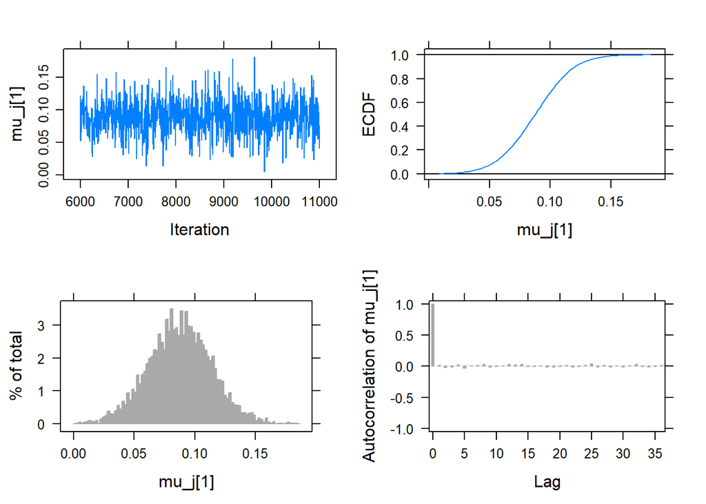

```r
plot(posterior, vars = "mu_j[1]")
```

question 2

```r
modelString <-"
model {

## likelihod
for(i in 1:N){
y[i] ~ dnorm(mu_j[schedule[i]], invsigma2)
}

## priors

for (j in 1:J){
mu_j[j] ~ dlnorm(mu, invtau2)
}

invsigma2 ~ dgamma(a_g, b_g)
sigma <- sqrt(pow(invsigma2, -1))

##hyperpriors
mu ~ dlnorm(mu0, 1/g0^2)
invtau2 ~ dgamma(a_t, b_t)
tau <- sqrt(pow(invtau2, -1))

}
"

y = dramadata$Rating        # The y values are in the column named Rating
schedule = dramadata$Schedule      # The schedule index is in the column named Schedule
N = length(y)  # Compute the number of observations
J = length(unique(schedule)) # Compute the number of schedules/subsamples

initsfunction <- function(chain){
  .RNG.seed <- c(1,2)[chain]
  .RNG.name <- c("base::Super-Duper",
                 "base::Wichmann-Hill")[chain]
  return(list(.RNG.seed=.RNG.seed,
              .RNG.name=.RNG.name))
}

the_data <- list("y" = y, "schedule" = schedule, "N" = N, "J" = J,
                 "mu0" = 0.1, "g0" = 0.5,
                 "a_t" = 1, "b_t" = 1,
                 "a_g" = 1, "b_g" = 1)

posterior <- run.jags(modelString,
                      n.chains = 1,
                      data = the_data,
                      monitor = c("mu", "tau", "mu_j", "sigma"),
                      adapt = 1000,
                      burnin = 5000,
                      sample = 5000,
                      thin = 1,
                      inits = initsfunction)
```

[output not shown]

```
## Finished running the simulation
```

```r
options(digits = 3)
summary(posterior)
```

```
##          Lower95 Median Upper95   Mean     SD Mode    MCerr MC%ofSD SSeff
## mu      2.46e-01 0.7955   1.645 0.8669 0.3894   NA 0.009171     2.4  1803
## tau     1.43e+00 3.2363   6.533 3.5867 1.5169   NA 0.039186     2.6  1498
## mu_j[1] 2.90e-02 0.0835   0.137 0.0829 0.0275   NA 0.000519     1.9  2796
## mu_j[2] 3.98e-02 0.0903   0.145 0.0902 0.0268   NA 0.000525     2.0  2603
## mu_j[3] 1.44e-07 0.0352   0.161 0.0531 0.0543   NA 0.002065     3.8   691
## mu_j[4] 7.88e-02 0.1355   0.194 0.1358 0.0292   NA 0.000523     1.8  3107
## sigma   1.31e-01 0.1517   0.174 0.1523 0.0108   NA 0.000163     1.5  4449
##            AC.10 psrf
## mu       0.02530   NA
## tau      0.04672   NA
## mu_j[1] -0.00733   NA
## mu_j[2]  0.02257   NA
## mu_j[3]  0.09736   NA
## mu_j[4]  0.00960   NA
## sigma    0.00752   NA
```

```
## Generating plots...
```

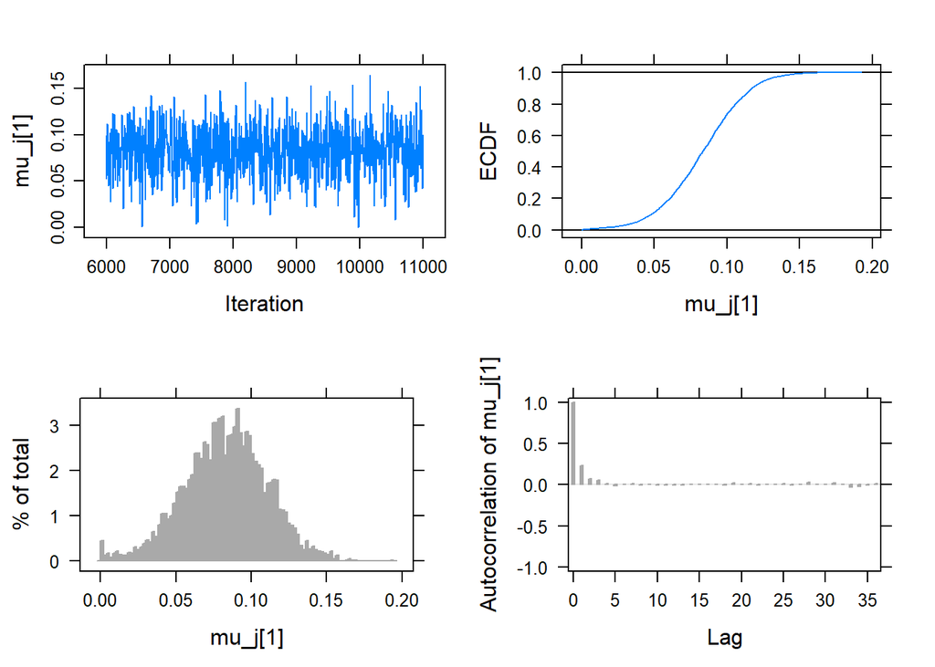

```r
plot(posterior, vars = "mu_j[1]")
```

The posterior draws of mu and mu1 through mu4 are indeed positive. The traceplot looks better than the truncated normal distribution in that it is more varied. However, the autocorrelation doesn’t drop down to 0 as quickly as it did in question one which implies it might need more thinning or a larger burn in.

question 3

```r
modelString <-"
model {

## likelihod
for(i in 1:N){
y[i] ~ dnorm(mu_j[schedule[i]], invsigma2)
}

## priors

for (j in 1:J){
mu_j[j] ~ dweibull(1, mu)T(0,)
}

invsigma2 ~ dgamma(a_g, b_g)
sigma <- sqrt(pow(invsigma2, -1))

##hyperpriors
mu ~ dlnorm(mu0, 1/g0^2)

}
"

y = dramadata$Rating        # The y values are in the column named Rating
schedule = dramadata$Schedule      # The schedule index is in the column named Schedule
N = length(y)  # Compute the number of observations
J = length(unique(schedule)) # Compute the number of schedules/subsamples

initsfunction <- function(chain){
  .RNG.seed <- c(1,2)[chain]
  .RNG.name <- c("base::Super-Duper",
                 "base::Wichmann-Hill")[chain]
  return(list(.RNG.seed=.RNG.seed,
              .RNG.name=.RNG.name))
}

the_data <- list("y" = y, "schedule" = schedule, "N" = N, "J" = J,
                 "mu0" = 0.1, "g0" = 0.5,
                 "a_t" = 1, "b_t" = 1,
                 "a_g" = 1, "b_g" = 1)

posterior <- run.jags(modelString,
                      n.chains = 1,
                      data = the_data,
                      monitor = c("mu", "tau", "mu_j", "sigma"),
                      adapt = 1000,
                      burnin = 5000,
                      sample = 5000,
                      thin = 1,
                      inits = initsfunction)
```

[output not shown]

```
## Finished running the simulation
```

```r
options(digits = 3)
summary(posterior)
```

```
##          Lower95 Median Upper95   Mean     SD Mode    MCerr MC%ofSD SSeff
## mu      7.27e-01 2.2952   4.842 2.5166 1.1463   NA 0.024856     2.2  2127
## mu_j[1] 3.64e-02 0.0874   0.139 0.0871 0.0258   NA 0.000456     1.8  3209
## mu_j[2] 4.44e-02 0.0932   0.146 0.0935 0.0257   NA 0.000479     1.9  2886
## mu_j[3] 8.43e-05 0.0670   0.192 0.0785 0.0580   NA 0.001343     2.3  1869
## mu_j[4] 7.91e-02 0.1390   0.194 0.1390 0.0293   NA 0.000504     1.7  3391
## sigma   1.31e-01 0.1519   0.175 0.1526 0.0112   NA 0.000166     1.5  4586
##            AC.10 psrf
## mu      -0.00797   NA
## mu_j[1]  0.00770   NA
## mu_j[2]  0.01443   NA
## mu_j[3] -0.00112   NA
## mu_j[4] -0.01082   NA
## sigma   -0.00665   NA
```

```
## Generating plots...
```

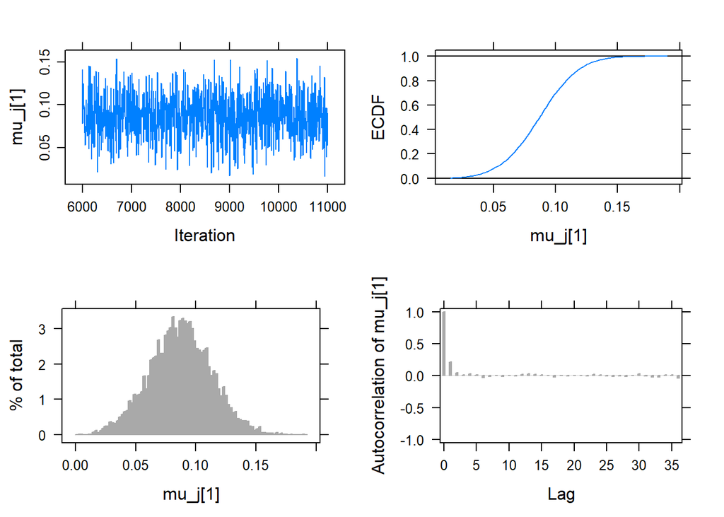

```r
plot(posterior, vars = "mu_j[1]")
```

The posterior draws of mu and mu1 through mu4 are indeed positive. This is using a weibull distribution prior with a log normal hyperprior. The autocorrelation looks very similar to question 2. It might be slightly better, but not by much. The traceplot is also varied. It would likely also benefit from a larger burn in and more thinning.